# Monitoreo y pronóstico de clorofila-a en zonas costeras utilizando datos del servicio Copernicus Marine Environment Monitoring Service (CMEMS)

Este código permite monitorear y pronosticar la concentración de clorofila-a en zonas costeras utilizando datos satelitales proporcionados por el servicio **Copernicus Marine Environment Monitoring Service (CMEMS).**

El catálogo de diferentes datasets está disponible en: https://marine.copernicus.eu/ y para poder acceder y descargar los datos es necesario registrarse gratuitamente en la plataforma.

Para acceder a los datos se utiliza Copernicus Marine Toolbox con su API en python, medienta la libreria `copernicusmarine`. Además se utilizan bibliotecas como `xarray`, `matplotlib` y `cartopy` para la manipulación de datos y la visualización geoespacial.

**Importante:** la libreria `copernicusmarine` permite hacer login interactivo y también automatizado. En este caso se utiliza el login automatizado mediante un archivo de configuración de credenciales, si no se tiene es necesario crearlo en el directorio de trabajo, la misma libreria permite generarlo:

```
import copernicusmarine
copernicusmarine.login()
```

**Descargamos los datos de clorofila-a satelitales y de pronóstico para una región costera específica.**

Los datasets utilizados son:

- **Observaciones:** [Global Ocean Colour (Copernicus-GlobColour)](https://data.marine.copernicus.eu/product/OCEANCOLOUR_GLO_BGC_L4_NRT_009_102/description), Bio-Geo-Chemical, L4 (monthly and interpolated) from Satellite Observations (Near Real Time)
- **Pronóstico:** [Global Ocean Biogeochemistry Analysis and Forecast](https://data.marine.copernicus.eu/product/GLOBAL_ANALYSISFORECAST_BGC_001_028/description).

Se seleccionan las últimas 3 fechas disponibles para observación (día anterior al actual es la más reciente) y 3 tiempos de pronóstico (el dia actual es el primer tiempo).

Se ingresan las coordenadas geográficas de la región costera de interés, además de un nombre descriptivo para la misma (evitar espacios).

Se descargan los datasets en formato netCDF y se almacenan en un directorio local para su posterior análisis y visualización. Los archivos se renombran de acuerdo a la fecha actual en el formato `YYYYMMDD_chlo_fcst.nc` (pronóstico) y `YYYYMMDD_chlo_obs.nc` (observación).

```
INFO - 2025-10-20T06:05:35Z - Selected dataset version: "202311"
INFO - 2025-10-20T06:05:35Z - Selected dataset part: "default"
INFO - 2025-10-20T06:05:38Z - Starting download. Please wait...
INFO - 2025-10-20T06:05:38Z - NetCDF compression enabled with level 9
INFO - 2025-10-20T06:05:39Z - Successfully downloaded to data\20251019_chlo_fcst.nc
```

[output not shown]

```
INFO - 2025-10-20T06:05:42Z - Selected dataset version: "202311"
INFO - 2025-10-20T06:05:42Z - Selected dataset part: "default"
INFO - 2025-10-20T06:05:54Z - Starting download. Please wait...
INFO - 2025-10-20T06:05:54Z - NetCDF compression enabled with level 9
INFO - 2025-10-20T06:05:55Z - Successfully downloaded to data\20251019_chlo_obs.nc
```

[output not shown]

Se generan los gráficos comparativos de concentración de clorofila-a para las fechas seleccionadas, mostrando tanto las observaciones satelitales como los pronósticos del modelo. Los gráficos incluyen mapas geoespaciales con proyecciones cartográficas adecuadas y barras de color para interpretar los niveles de clorofila-a.

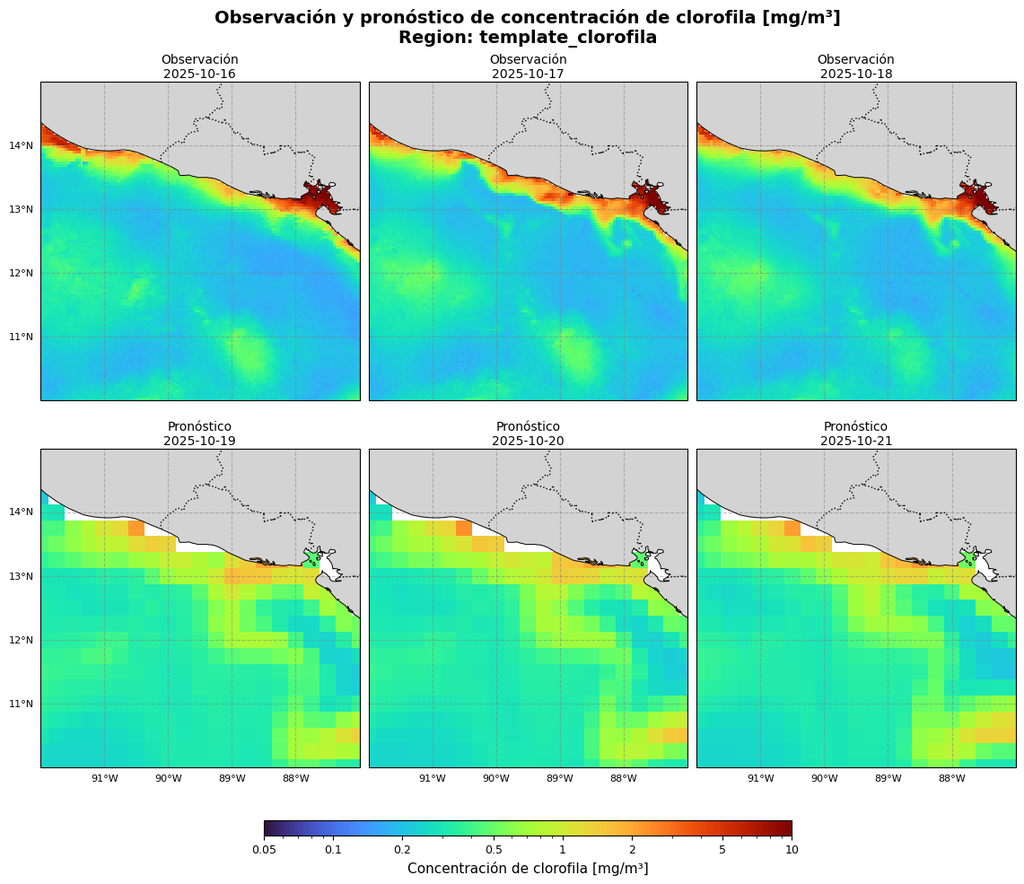

[output not shown]